None

# Table of Contents

## Potential Flow

```python
import numpy as np
import matplotlib.pyplot as plt
```

### General Terminology

#### Streamfunction and Complex Potential

Potential flow fields are given by analytical solutions of the Laplace equation, i.e. explicit formulae. The velocity vector is given by $\mathbf{v} =-\nabla \phi $, where $\phi $ denotes the scalar potential field - in 2D in detail:

\begin{equation} v_x = - \frac{\partial \phi}{\partial x} \text{ and } v_y = - \frac{\partial \phi}{\partial y} \end{equation}

In addition there is a complementary function $ \psi $, called the **streamfunction**. The streamfunction has the nice property that *streamlines* can be visualized as contour lines. The components of the velocity can also be obtained from the streamfunction:

\begin{equation} v_x = - \frac{\partial \psi}{\partial y} \text{ and } v_y = \frac{\partial \psi}{\partial x} \end{equation}

Here we utilize the shorter notation using the **complex potential** $ \Phi = \phi + i\psi$ that combines both real-valued functions to a complex-valued function. The real part of the complex potential is what is usually called simply the potential. Dealing with potential flow the imaginary part of the complex potential is called the streamfunction.

Potential flow is especially important in 2D, where there are many applications, for example in laminar flow or porous media flow (Holzbecher 2019). The textbook of Strack (1989) is the standard source for the use of potential flow concepts in groundwater flow modeling. For the application in aerodynamics see the book of Anderson (2017). For applications in electrostatics see Antohe & Antohe (2023).

In fluid flow, i.e hydrodynamics and aerodynamics, the physical unit of the complex potential and both of its parts is [area/time], or [m$^2$/s] in standard units. In order to distinguish this from applications in other fields, where different physical units have to be taken, the term **velocity potential** can be often found for $\phi$. In electrostatics or electrodynamics its unit is [Volt].

Using complex analysis for potential flow is a powerful method, which famous mathematicians, physicists and engineers have developed over centuries. However, it can be applied only under certain conditions:

- flow is stationary, i.e. time-independent
- flow is incompressible, i.e. $ \nabla \cdot \nabla \Phi$ = 0, (or div(grad $\Phi$) = 0) or divergence free
- flow is irrotational, i.e. $ \nabla \times \nabla \Phi $ = 0. (or rot(grad $\Phi$) = 0) or curl free

In this lecture we deal with 2-dimensional flow only, because we want to show the connection with complex analysis, which deals with functions on the 2D complex plane. For real 3D flow to be studied using the 2D means that the flow is in dependent of the third dimension (usually denoted by $z$). Sinks and sources in 2D flow thus represent line sinks and line sources in 3D space.

The incompressibility condition mentioned above is also written as

\begin{equation} (\frac{\partial ^2}{\partial x^2} + \frac{\partial ^2}{\partial y^2} + \frac{\partial ^2}{\partial z^2}) \Phi = 0 \text{ in 3D} \end{equation}\begin{equation} (\frac{\partial ^2}{\partial x^2} + \frac{\partial ^2}{\partial y^2}) \Phi = 0 \text{ in 2D} \end{equation}

or simpler: $\Delta \Phi = 0 $. These are just different writings of the **Laplace equation**.

#### Vorticity and Pressure

Another function that is used in hydromechanics is the **vorticity**, that is defined by:

\begin{equation} \omega = \nabla \times \pmb{v} \end{equation}

According to its definition the vorticity is a vector. In 2D flow the velocity is independent of the $z$-coordinate, the vorticity vector is perpendicular to the $(x,y)$-plane and parallel to the $z$-axis, and therefore can be expressed by a scalar function. The irrotationality charactistic above means that the vorticity is zero. Physically that means that individual fluid elements do not rotate, or distort, as they move through the flow field. The transport of vorticity is relevant feature in many applications, but not in potential flow.

In textbooks of hydromechanics the Bernouilly equation (in reference to the Swiss mathematician Jacob Bernoulli, 1655-1705) is derived for the simplified cases, in which viscosity effects are neglected, i.e. the curl-free case, as in potential flow:

\begin{equation} \nabla (\frac{\partial \phi}{\partial t} + \frac{P}{\rho} + \frac{1}{2}\pmb{v} \cdot \pmb{v} -g z ) = 0 \end{equation}

where $P$ denotes total pressure, $\rho$ fluid density and $g$ the acceleration due to gravity. For steady potential flow that can be simplified to a relation between the dynamic pressure $ p = P - \rho g z$ and velocity:

\begin{equation} p + \frac{1}{2} \rho \pmb{v} \cdot \pmb{v} = const \end{equation}

The equation shows that pressure is lower, where velocity is higher, and vice versa that pressure is higher where velocity is lower. This principle is fundamental for the lift forces and explains, why planes fly.

#### Electrostatics

The electric field is a vector field describing the force experienced by a positive charge. If the field is time independend, i.e. stationary or steady, the electric field $\pmb{E}$ fulfills the Maxwell equations. In a 2D setting these are written like this \begin{equation} \partial_x E_y - \partial_y E_x = 0 \end{equation} \begin{equation} \qquad \partial_x E_x + \partial_y E_y = 4 \pi \rho \end{equation} where $\pmb{E} = (E_x,E_y)$ and $\rho$ is the surface charge density. If the domain is charge-free, i.e. $\rho=0$, functions $\phi $ and $ \psi $ can be defined that fulfill the equations: \begin{equation} E_x = - \frac{\partial \phi}{\partial x} \text{ and } E_y = - \frac{\partial \phi}{\partial y} \end{equation} \begin{equation} E_x = - \frac{\partial \psi}{\partial y} \text{ and } E_y = \frac{\partial \psi}{\partial x} \end{equation} Thus $\phi $ and $ \psi $ fulfill the Cauchy-Riemann equations: $$ \partial_x \phi = \partial_y \psi, \qquad \partial_y \phi = - \partial_x \psi $$ Using complex analysis methodology the two functions can be combined to form the complex potential $ \Phi = \phi + i\psi$. In electrostatics we call $\phi $ the electrostatic potential and $ \psi $ the streamfunction. $\phi $ is tangential to the line of force, while the contours of $\psi $ are curves along which the electrical field acts - the *lines of force*.

### Uniform Flow

Uniform flow is the most simple example of potential flow. It is given by the complex potential:

\begin{equation} \Phi = -\overline{Q_0} \cdot z \end{equation}

$Q_0$ is the velocity vector in complex coordinates, i.e it is a complex number for which real and imaginary parts represent the two vector components. The overline in the formula above stands for the conjugate complex. The following contour plot shows uniform flow along the $x$-axis. For the velocity potential the flux between the streamlines, coloured in white, is the same. We call it a **streamtube**.

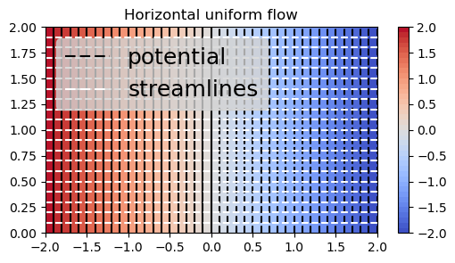

```python
fig, ax = plt.subplots(figsize=(6,3))
xmin = -2; xmax = 2; ymin = 0; ymax = 2; Q0 = 1+0j;
x = np.linspace(xmin,xmax,40); y = np.linspace(ymin,ymax,20)
[X,Y] = np.meshgrid (x,y); Z = X+1j*Y                               # complex mesh
Phi = -np.conj(Q0)*Z                                                # uniform flow

plt.contourf (X,Y,np.real(Phi),40,cmap='coolwarm');
plt.colorbar()
cnt1 = plt.contour (X,Y,np.real(Phi),40,colors='k');
h1,_ = cnt1.legend_elements()
cnt2 = plt.contour (X,Y,np.imag(Phi),20,colors='white');
h2,_ = cnt2.legend_elements()
plt.legend = ax.legend([h1[0],h2[0]],['potential','streamlines'],frameon = True,facecolor='lightgray',fontsize=18, loc=2)
ax.set_title('Horizontal uniform flow')
plt.show()
```

[figure not shown]

Let's change the angle of flow!

[figure not shown]

```python
fig, ax = plt.subplots(figsize=(4, 4))
xmin = -1; xmax = 1; ymin = -1; ymax = 1; Q0 = 1+1j;
x = np.linspace(xmin,xmax,100); y = np.linspace(ymin,ymax,100)
[X,Y] = np.meshgrid (x,y); Z = X+1j*Y                               # complex mesh
Phi = -np.conj(Q0)*Z                                                # uniform flow

plt.contourf (X,Y,np.real(Phi),40,cmap='coolwarm')
cnt1 = plt.contour (X,Y,np.real(Phi),40,colors='k')
h1,_ = cnt1.legend_elements()
cnt2 = plt.contour (X,Y,np.imag(Phi),20,colors='white')
h2,_ = cnt2.legend_elements()
plt.legend = ax.legend([h1[0],h2[0]],['potential','streamlines'],frameon = True,facecolor='lightgray',fontsize=18, loc=2)
ax.set_title('Diagonal uniform flow')
plt.show()
```

### Sink or Source in a Uniform Flow Field

Lets look at a flow pattern that emerges, when a source or sink is placed in a uni-directional flow field. The sink/source is located at the coordinates $ z_0 = x_0 + iy_0). $ $Q$ denotes the sink/source rate and $Q_0$ uniform baseflow per unit thickness. For positive values of $Q$ there is a source at the position $z_0$, for negative values it is a sink!

\begin{equation} \Phi = -\overline{Q_0} \cdot z - \frac{Q}{2\pi} \text{log}(z-z_0) \end{equation}

The first term in the formula represents the baseflow, the second the sink/source. The latter is expressed by the complex logarithm. Constructing flow by simply summing up the contributions is allowed accoring to the **principle of superposition**.

Lets look at a flow pattern that emerges, when a source or sink is placed in a uni-directional flow field. In applications on groundwater that represents a well in a regional flow field. The sink/source is located at the coordinates $ (x_0,y_0) $. Here is the visualization using filled contours for the potential and plain contours for the streamfunction.

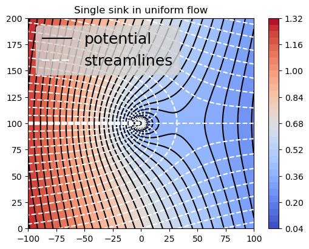

```python
fig, ax = plt.subplots(figsize=(6,4.5))
xmin = -100; xmax = 100; ymin = 0; ymax = 200; Q0 = 0.005+0j; Q = -1; z0 = 0+100j
x = np.linspace(xmin,xmax,100); y = np.linspace(ymin,ymax,100)
[X,Y] = np.meshgrid (x,y); Z = X+1j*Y                                 # complex mesh
Phi =  -np.conj(Q0)*Z - Q*np.log(Z-z0)/2/np.pi                        # baseflow + sink

plt.contourf (X,Y,np.real(Phi),40,cmap='coolwarm')
plt.colorbar()
cnt1 = plt.contour (X,Y,np.real(Phi),40,colors='k')
h1,_ = cnt1.legend_elements()
cnt2 = plt.contour (X,Y,np.imag(Phi),20,colors='white')
h2,_ = cnt2.legend_elements()
plt.legend = ax.legend([h1[0],h2[0]],['potential','streamlines'],frameon = True,facecolor='lightgray',fontsize=18, loc=2)
ax.set_title('Single sink in uniform flow')
plt.show()
```

Fluid is entering from the left with high potential values. Some of it is leaving the domain on the right with low potential values. Part of the fluid is captured on the way by the sink. The catchment of the sink can clearly be delineated. Fluid that enters between positions 20 and 180 on the left ends up in the sink, while fluid that enters beyond makes it all way through to the right. This potential has an important applications in groundwater flow, where it can help to determine convenient locations and abstraction rates of wells.

The velocity for this potential is given by derivation:

\begin{equation} \pmb{v} = -Q_0 - Q/(2\pi (z-z_0)) \end{equation}

There is a stagnation point downstream from the sink, where velociy direction change. The last equation can be modified easily to determine the position of the stagnation point, which is characterized by $\textbf{v}=0$.

\begin{equation} x_s = x_0 - Q/(2\pi Q_0) \end{equation}

```python
xs = np.real(z0) - Q/2/np.pi/np.real(Q0)
display ('Stagnation point at position on axis through well: '+str(xs))
```

```
'Stagnation point at position on axis through well: 31.83098861837907'
```

Let's improve the visualization by marking the stagnation point and the catchment of the well by red colors. The catchment is delineated by limit streamlines. In order to find those, we need the strremfunction value at thew stagnation point. Moreover, we use the 'quiver' function of the 'matplotlib' library to add arrows for indicating the direction!

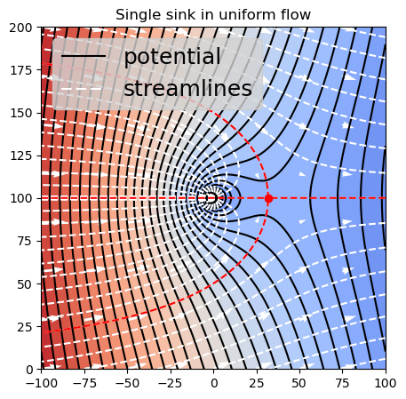

```python
fig, ax = plt.subplots(figsize=(5, 5))
xmin = -100; xmax = 100; ymin = 0; ymax = 200; Q0 = 0.005+0j; Q = -1; z0 = 0+100j
x = np.linspace(xmin,xmax,100); y = np.linspace(ymin,ymax,100)
[X,Y] = np.meshgrid (x,y); Z = X+1j*Y                               # complex mesh
Phi = -np.conj(Q0)*Z - Q*np.log(Z-z0)/2/np.pi                       # baseflow + sink

plt.contourf (x,y,np.real(Phi),40,cmap='coolwarm')
cnt1 = plt.contour (X,Y,np.real(Phi),40,colors='k')
h1,_ = cnt1.legend_elements()
cnt2 = plt.contour (X,Y,np.imag(Phi),20,colors='white')
h2,_ = cnt2.legend_elements()
plt.legend = ax.legend([h1[0],h2[0]],['potential','streamlines'],frameon = True,facecolor='lightgray',fontsize=18, loc=2)

plt.plot(xs,np.imag(z0),'ro')                                       # plot stagnation point
zs = xs + 1j*np.imag(z0)
phis =  -np.conj(Q0)*zs - Q*np.log(zs-z0)/2/np.pi                   # potential at stagnation point
plt.contour (X,Y,np.imag(Phi),levels=[np.imag(phis)],colors ='red')

x = np.linspace(xmin, xmax, 9); y = np.linspace(ymin,ymax,8)
[X,Y] = np.meshgrid (x,y); Z = X+1j*Y                               # complex mesh
Phi =  -np.conj(Q0)*Z - Q*np.log(Z-z0)/2/np.pi                      # baseflow + sink
[V,U] = np.gradient(np.real(Phi))                                   # velocity components
plt.quiver(X,Y,-U,-V,color='white')

ax.set_title('Single sink in uniform flow')
plt.show()
```

In the first two new command lines a new much coarser mesh is specified and the potential is computed on this new mesh. The following statement includes the 'gradient' of numpy, which calculates two fields containing the gradients of the array in each of the two coordinate directions. According to the definition of potential flows (see above) they represent the velocity, but with the opposite sign. This is considered by the two negative signs in the following 'quiver' function, which plots the arrow field.

The following example demonstrates the application of the 'streamplot' function that plots streamlines with direction arrows. It is not necessary to define a coarser mesh.

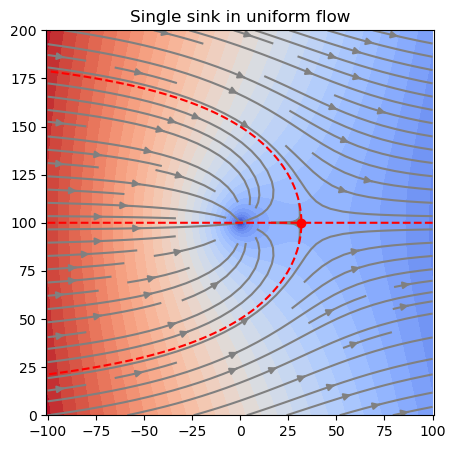

```python
fig, ax = plt.subplots(figsize=(5, 5))
xmin = -100; xmax = 100; ymin = 0; ymax = 200; Q0 = 0.005+0j; Q = -1; z0 = 0+100j
x = np.linspace(xmin,xmax,100); y = np.linspace(ymin,ymax,100)
[X,Y] = np.meshgrid (x,y); Z = X+1j*Y                               # complex mesh
Phi =  -np.conj(Q0)*Z - Q * np.log(Z-z0)/2/np.pi                    # baseflow + sink
[V,U] = np.gradient(np.real(Phi))                                   # velocity components

plt.contourf (x,y,np.real(Phi),40,cmap='coolwarm')
ax.streamplot(X,Y,-U,-V,color='gray')

plt.plot(xs,np.imag(z0),'ro')                                       # plot stagnation point
zs = xs + 1j*np.imag(z0)
phis =  -np.conj(Q0)*zs - Q*np.log(zs-z0)/2/np.pi                   # potential at stagnation point
plt.contour (X,Y,np.imag(Phi),levels=[np.imag(phis)],colors ='red')
ax.set_title('Single sink in uniform flow')
plt.axis('equal')
plt.show()
```

We can make the color of the streamline dependent on the size of the velocity. This is demonstrated in the following.

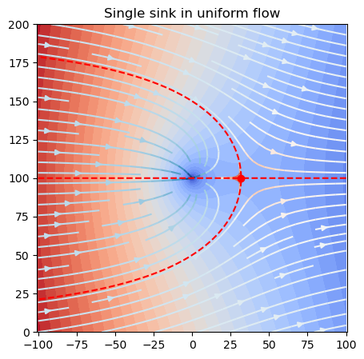

```python
fig, ax = plt.subplots(figsize=(5,5))
xmin = -100; xmax = 100; ymin = 0; ymax = 200; Q0 = 0.005+0j; Q = -1; z0 = 0+100j
x = np.linspace(xmin,xmax,100); y = np.linspace(ymin,ymax,100)
[X,Y] = np.meshgrid (x,y); Z = X+1j*Y                               # complex mesh
Phi =  -np.conj(Q0)*Z - Q*np.log(Z-z0)/2/np.pi                      # baseflow + sink
[V,U] = np.gradient(np.real(Phi))                                   # velocity components
W = np.log(np.sqrt(U*U+V*V))                                        # size of velocity, log scale

plt.contourf (X,Y,np.real(Phi),40,cmap='coolwarm')
ax.streamplot(X,Y,-U,-V,color=W,cmap='RdBu')
#lw = 0.4*np.log(abs(W/W.max()))
#ax.streamplot(X, Y, -U, -V, density=0.6, color='k', linewidth=lw)

plt.plot(xs,np.imag(z0),'ro')                                       # plot stagnation point
zs = xs + 1j*np.imag(z0)
phis =  -np.conj(Q0)*zs - Q*np.log(zs-z0)/2/np.pi                   # potential at stagnation point
plt.contour (X,Y,np.imag(Phi),levels=[np.imag(phis)],colors ='red')
ax.set_title('Single sink in uniform flow')
plt.axis('equal')
plt.show()
```

The colormap 'RdBu' shows high values in blue and low values in red. See that lines get blue in the close vicinity of the sink. Lowest velocity values can be found in the wake of the sink, near to the stagnation point.

**Task 1**: Explore the flow pattern, if you change the uniform flow, pumping rate, and switch from the sink to a source!

The following results for negative baseflow towards a source.

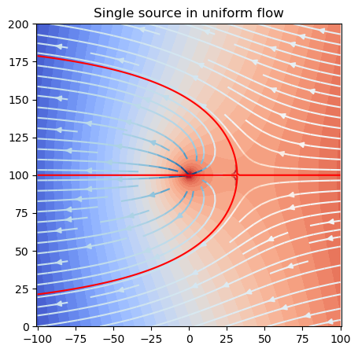

```python
fig, ax = plt.subplots(figsize=(5,5))
xmin = -100; xmax = 100; ymin = 0; ymax = 200; Q0 = -0.005+0j; Q = 1; z0 = 0+100j
x = np.linspace(xmin,xmax,100); y = np.linspace(ymin,ymax,100)
[X,Y] = np.meshgrid (x,y); Z = X+1j*Y                               # complex mesh
Phi =  -np.conj(Q0)*Z - Q*np.log(Z-z0)/2/np.pi                      # baseflow + sink
[V,U] = np.gradient(np.real(Phi))                                   # velocity components
W = np.log(np.sqrt(U*U+V*V))                                        # size of velocity, log scale

plt.contourf (X,Y,np.real(Phi),40,cmap='coolwarm')
ax.streamplot(X,Y,-U,-V,color=W,cmap='RdBu')

xs = np.real(z0) - Q/2/np.pi/np.real(Q0)
zs = xs + 1j*np.imag(z0)                                            # stagnation point
phis =  -np.conj(Q0)*zs - Q*np.log(zs-z0)/2/np.pi                   # potential at stagnation point
plt.contour (X,Y,np.imag(Phi),levels=[np.imag(phis)],colors ='red')
ax.set_title('Single source in uniform flow')
plt.axis('equal')
plt.show()
```

In the literature this pattern is often referred to as flow towards a **Rankine half body**, named after the Scottish mathematician and phsicist William Rankine (1820-1872). The width of the body at the source location is $Q/(2 Q_0)$. The body has a maximum width of $Q/Q_0$.

### Doublet

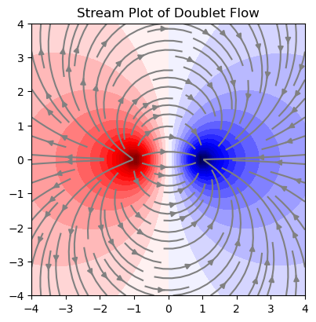

```python
fig, ax = plt.subplots(figsize=(4.5,4.5))
xmin = -4; xmax = 4; ymin = -4; ymax = 4
x = np.linspace(xmin,xmax,40); y = np.linspace(ymin,ymax,40)
[X,Y] = np.meshgrid (x,y); Z = X+1j*Y                               # complex mesh
# Phi = (np.log((Z-1))-np.log(Z+1))/2/np.pi
Phi =  np.log((Z-1)/(Z+1))/2/np.pi                                  # source + sink
[V,U] = np.gradient(np.real(Phi))                                   # velocity components

plt.contourf (X,Y,np.real(Phi),40,cmap='seismic')
ax.streamplot(X,Y,-U,-V,color='gray')
ax.set_title('Stream Plot of Doublet Flow')
plt.show()
```

**Task 2**: Show flow in the vicinity of a doublet in a uniform flow field that is aligned with the doublet axis!

**Task 3**: Show flow in the vicinity of a doublet in a uniform flow field that has a 45$^{\circ}$ angle with the doublet axis!

### Multiple Sources and Sinks

The following program can deal with multiple sinks and sources in a uniform flow field. The 'for'-loop allows to add up the contributions from several wells.

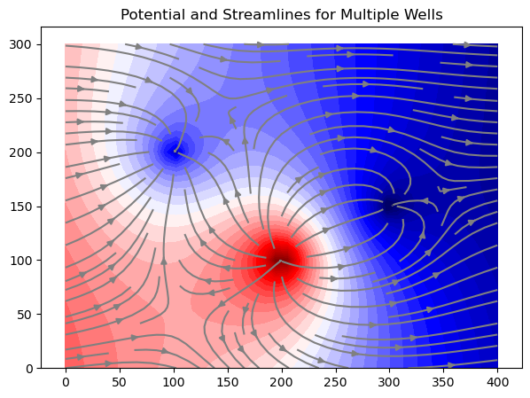

```python
fig, ax = plt.subplots(figsize=(7,5))
xmin = 0; xmax = 400; ymin = 0; ymax = 300
Q0 = 1.e-4; Q = 0.05*np.array([-1,2,-1])
x0 = np.array([100,200,300]); y0 = np.array([200,100,150])
x = np.linspace(xmin,xmax,40); y = np.linspace(ymin,ymax,40)
[X,Y] = np.meshgrid (x,y); Z = X+1j*Y                               # complex mesh
Phi =  -np.conj(Q0)*Z                                               # baseflow + sinksources
for i in range (np.size(Q)):
    Phi = Phi - Q[i]*np.log(Z-x0[i]-1j*y0[i])/2/np.pi

[V,U] = np.gradient(np.real(Phi))                                   # velocity components

plt.contourf (X,Y,np.real(Phi),40,cmap='seismic')
ax.streamplot(X,Y,-U,-V,color='gray')
ax.set_title('Potential and Streamlines for Multiple Wells')
plt.axis('equal')
plt.show()
```

The example has two sinks and one source. One can follow the streamlines to see the regions which connect the sinks with the sources. It can be obsrved that one of the sinks is completely connected to the source, while the other sink also receives input from the baseflow field, entering from outside of the shown domain.

### Dipole

A dipole is like a doublet. However, in comparison to the spatial scale of interest both pole are located so close to each other that they can be considered as one site. The complex potential for the dipole is

\begin{equation} \Phi = \mu \frac{\text{exp}(i\alpha )}{2\pi (z-z_0)} \end{equation}

$\mu$ determines the strength of the dipole, $\alpha$ is an angle standing for the direction of the two poles. The following code creates a visualization of two plots, which demonstrate the use of the $\alpha$ parameter.

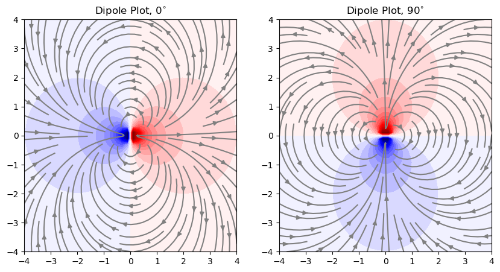

```python
fig = plt.figure(figsize=(10,5))

def dipole(Z):
    global mu, alpha, z0
    Phi =  mu*np.exp(1j*alpha)/2/np.pi/(Z-z0)
    return Phi

xmin = -4; xmax = 4; ymin = -4; ymax = 4
z0 = 0 + 0*1j; mu = 1; alpha = 0
x = np.linspace(xmin,xmax,40); y = np.linspace(ymin,ymax,40)
[X,Y] = np.meshgrid (x,y); Z = X+1j*Y                               # complex mesh
Phi = dipole(Z); [V,U] = np.gradient(np.real(Phi))                  # dipole 1

ax = fig.add_subplot(1,2,1)
plt.contourf (X,Y,np.real(Phi),40,cmap='seismic')
ax.streamplot(X,Y,-U,-V,color='gray')
ax.set_title('Dipole Plot, 0$^{\circ}$')

alpha = np.pi/2;
Phi = dipole(Z); [V,U] = np.gradient(np.real(Phi))                  # dipole 2
ax = fig.add_subplot(1,2,2)
plt.contourf (X,Y,np.real(Phi),40,cmap='seismic')
ax.streamplot(X,Y,-U,-V,color='gray')
ax.set_title('Dipole Plot, 90$^{\circ}$')
plt.show()
```

Note that the program is structured a bit differently. A 'dipole' function is written first. When called it returns the complex potential of the dipole. In the main program the function is called twice, in order to produce the two plots. The function has only one input parameter 'Z', which here contains the matrix of points in the complex plane. It has the given the same name as in the main program, which is not necessary. The matrix 'Z'in the function exists only during the execution of the function. The other parameters ($ \mu, \alpha, z_0$) are declared global. That means their values are taken from and remain identical to those in the instance where they come from - here the main program.

Let's combine the dipole with uniform flow! We utilize the previously defined a function for the dipole.

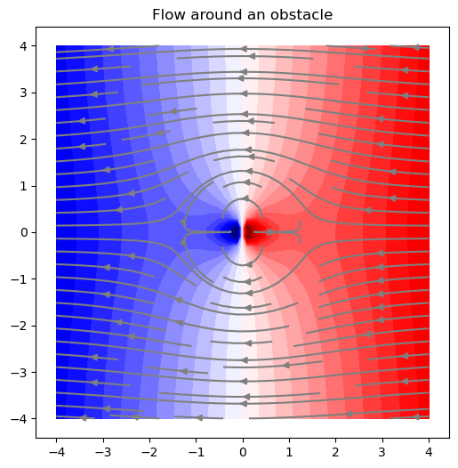

```python
fig, ax = plt.subplots(figsize=(6,6))
xmin = -4; xmax = 4; ymin = -4; ymax = 4
z0 = 0 + 0*1j; mu = 1; alpha = 0; Q0 = 0.1 + 0*1j
x = np.linspace(xmin,xmax,40); y = np.linspace(ymin,ymax,40)
[X,Y] = np.meshgrid (x,y); Z = X+1j*Y                               # complex mesh
Phi = np.conj(Q0)*Z+dipole(Z);                                      # uniform flow and dipole
[V,U] = np.gradient(np.real(Phi))

plt.contourf (X,Y,np.real(Phi),40,cmap='seismic')
ax.streamplot(X,Y,-U,-V,color='gray')
ax.set_title('Flow around an obstacle')
plt.axis('equal')
plt.show()
```

The uniform flow field passes around the dipole as a round obstacle. It can be shown that the velocity is given by the formula

\begin{equation} v(z) = Q_0-\mu \frac{\text{exp}(i\alpha )}{2\pi (z-z_0)^2} \end{equation}

which vanishes at a circle of radius $R=\sqrt{\frac{\mu}{2\pi\ Q_0}}$ around the dipole center.

```python
R = np.sqrt(mu/2/np.pi/Q0)
display ('Circle radius: '+str(np.real(R)))
```

```
'Circle radius: 1.26156626101008'
```

### Boundary Conditions

Let's start with the situation in which an horizontal line is supposed the be no-flow boundary. A solid wall is a good example for such a boundary. The trick consists of the introduction of so-called mirror well. The situation in the sketch below illustrates the procedure. If there is a sink at the location above the wall, as shown, and an imaginary sink of same strength placed in the mirror position beyond the horizontal boundary, there will be no crossing streamlines the boundary. That means the boundary acts like a solid wall. The same effect is achieved for a source, if a source is placed at the mirror position.

[figure not shown]

Let's explore this with a code that is a slight modification of the program that models the doublet.

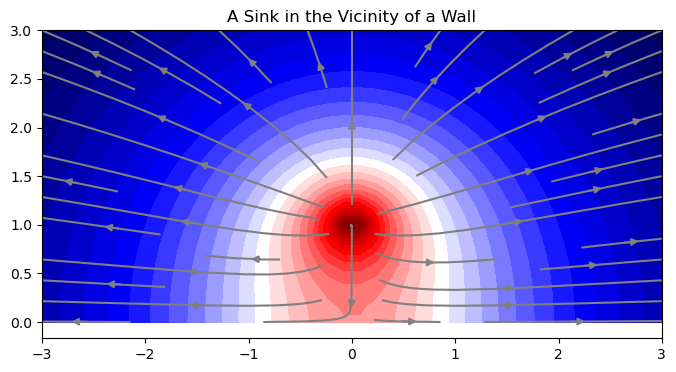

```python
fig, ax = plt.subplots(figsize=(8,4))
xmin = -3; xmax = 3; ymin = 0; ymax = 3
x = np.linspace(xmin,xmax,40); y = np.linspace(ymin,ymax,40)
[X,Y] = np.meshgrid (x,y); Z = X+1j*Y                                 # complex mesh
Phi =  -(np.log((Z-1j))+np.log(Z+1j))/2/np.pi                         # two sinks
[V,U] = np.gradient(np.real(Phi))                                     # velocity components

plt.contourf (X,Y,np.real(Phi),30,cmap='seismic')
ax.streamplot(X,Y,-U,-V,density = 0.5,color='gray')
ax.set_title('A Sink in the Vicinity of a Wall')
plt.show()
```

**Task 4**: Change the code for modeing a source near the boundary!

**Task 5**: Rewrite the code to model a sink near a vertical boundary with no-flow condition

Let's now come to another type of cboundary condition: the constant potential boundary.

For a demonstration the code above has been changed only slightly!

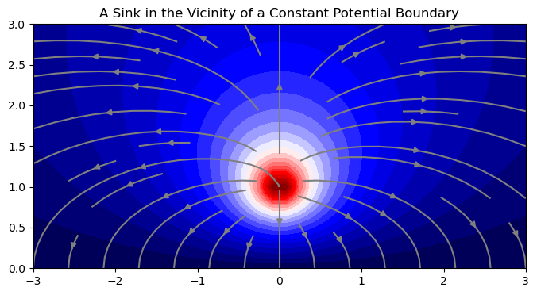

```python
fig, ax = plt.subplots(figsize=(8,4))
xmin = -3; xmax = 3; ymin = 0; ymax = 3
x = np.linspace(xmin,xmax,40); y = np.linspace(ymin,ymax,40)
[X,Y] = np.meshgrid (x,y); Z = X+1j*Y                                 # complex mesh
Phi =  (-np.log((Z-1j))+np.log(Z+1j))/2/np.pi                         # sink + source
[V,U] = np.gradient(np.real(Phi))                                     # velocity components

plt.contourf (X,Y,np.real(Phi),30,cmap='seismic')
ax.streamplot(X,Y,-U,-V,density = 0.5,color='gray')
ax.set_title('A Sink in the Vicinity of a Constant Potential Boundary')
plt.show()
```

**Task 6**: Consider uniform flow in addition!